# Causal Inference via Matching in R

Victoria L. Prince, Research Computing Services, HBS

# 1 Setup

## 1.1 Software and Prerequisites

This is an intermediate R course:

- Assumes working knowledge of R
- Relatively fast-paced

Follow these [R Installation](https://iqss.github.io/dss-workshops/Rinstall.html) instructions and ensure that you can successfully start RStudio.

Ask questions at any time during the workshop!

## 1.2 Goals

We will learn about the tools available in R to perform matching for the purpose of causal inference. We will also practice going through a recommended workflow for executing some of the matching algorithms. In particular, our goals are to learn about:

- Estimating treatment effect in experimental data
- Adjusting for covariates in observational studies
- Balance checking between exposure group and control group
- Identifying regions of common support
- R tools for matching
- Matching workflow

## 1.3 Launch an R session

Start RStudio and create a new project:

- On Windows click the start button and search for RStudio. On Mac RStudio will be in your applications folder.
- In Rstudio go to `File -> New Project`.
- Choose `Existing Directory` and browse to the workshop materials directory on your desktop.
- Choose `File -> New File` and select an `R Script`.

## 1.4 Packages

Let’s install (if needed) and load R packages that will aid with data loading and wrangling:

```r
# install.packages("tidyverse")
library(tidyverse)

# install.packages("haven")
library(haven)
```

Next, lets add some packages that will help with matching:

```r
# install.packages("MatchIt")
library(MatchIt) # for propensity score matching

# install.packages("cem")
library(cem) # for coarsened exact matching

# install.packages("RItools")
library(RItools) # for displaying balance statistics

# install.packages("cobalt")
library(cobalt) # for displaying balance statistics
```

# 2 NSW Example

We will use a classic example data set from a National Supported Work (NSW) Study conducted in 1970’s and designed to test whether and to what extent a temporary employment in a supportive but performance-oriented environment would help hard-to-employ people to get and hold normal jobs.

## 2.1 Background

Here are some facts about the study and subsequent use of the data it generated:

- Multisite randomized experiment; found that training raised yearly earnings by about $800 for male participants.
- Lalonde (1986) tried to use (then) existing non-experimental methods to recover this effect:
  - Used randomized treatment group, but replaced the control group with comparison groups from large publicly available datasets, including the Current Population Survey (CPS) and the Population Survey of Income Dynamics (PSID).
  - Caveat - used almost everyone from the selected surveys!
  - Found that none of the tried methods did very well; results all over the place (-$16,000 to $7,000)
- Dehejia and Wahba (DW, 1999) used the matching approach to select people from the CPS **who looked the most similar to the treated individuals** and were able to recover the effect from the experiment.

Let’s load the data and examine it.

```r
## Data is hosted on one of the authors' web-site
## Note that this data set is a subset of the original data,
## excluding subject with missing information on prior earnings
nsw_dw <- haven::read_dta("http://www.nber.org/~rdehejia/data/nsw_dw.dta")

PSID <- haven::read_dta("http://www.nber.org/~rdehejia/data/psid_controls.dta")

## If the server seems overloaded, please load locally:
# nsw_dw <- haven::read_dta("data/nsw_dw.dta")
# PSID <- haven::read_dta("data/psid_controls.dta")
```

```r
# Examine the NSW data
dim(nsw_dw)
```

```
## [1] 445  11
```

```r
str(nsw_dw)
```

```
## tibble [445 × 11] (S3: tbl_df/tbl/data.frame)
##  $ data_id  : chr [1:445] "Dehejia-Wahba Sample" "Dehejia-Wahba Sample" "Dehejia-Wahba Sample" "Dehejia-Wahba Sample" ...
##   ..- attr(*, "format.stata")= chr "%20s"
##  $ treat    : num [1:445] 1 1 1 1 1 1 1 1 1 1 ...
##   ..- attr(*, "format.stata")= chr "%9.0g"
##  $ age      : num [1:445] 37 22 30 27 33 22 23 32 22 33 ...
##   ..- attr(*, "format.stata")= chr "%9.0g"
##  $ education: num [1:445] 11 9 12 11 8 9 12 11 16 12 ...
##   ..- attr(*, "format.stata")= chr "%9.0g"
##  $ black    : num [1:445] 1 0 1 1 1 1 1 1 1 0 ...
##   ..- attr(*, "format.stata")= chr "%9.0g"
##  $ hispanic : num [1:445] 0 1 0 0 0 0 0 0 0 0 ...
##   ..- attr(*, "format.stata")= chr "%9.0g"
##  $ married  : num [1:445] 1 0 0 0 0 0 0 0 0 1 ...
##   ..- attr(*, "format.stata")= chr "%9.0g"
##  $ nodegree : num [1:445] 1 1 0 1 1 1 0 1 0 0 ...
##   ..- attr(*, "format.stata")= chr "%9.0g"
##  $ re74     : num [1:445] 0 0 0 0 0 0 0 0 0 0 ...
##   ..- attr(*, "format.stata")= chr "%9.0g"
##  $ re75     : num [1:445] 0 0 0 0 0 0 0 0 0 0 ...
##   ..- attr(*, "format.stata")= chr "%9.0g"
##  $ re78     : num [1:445] 9930 3596 24909 7506 290 ...
##   ..- attr(*, "format.stata")= chr "%9.0g"
```

```r
head(nsw_dw)
```

```
## # A tibble: 6 x 11
##   data_id treat   age education black hispanic married nodegree  re74  re75
##   <chr>   <dbl> <dbl>     <dbl> <dbl>    <dbl>   <dbl>    <dbl> <dbl> <dbl>
## 1 Deheji…     1    37        11     1        0       1        1     0     0
## 2 Deheji…     1    22         9     0        1       0        1     0     0
## 3 Deheji…     1    30        12     1        0       0        0     0     0
## 4 Deheji…     1    27        11     1        0       0        1     0     0
## 5 Deheji…     1    33         8     1        0       0        1     0     0
## 6 Deheji…     1    22         9     1        0       0        1     0     0
## # … with 1 more variable: re78 <dbl>
```

```r
summary(nsw_dw)
```

```
##    data_id              treat             age          education
##  Length:445         Min.   :0.0000   Min.   :17.00   Min.   : 3.0
##  Class :character   1st Qu.:0.0000   1st Qu.:20.00   1st Qu.: 9.0
##  Mode  :character   Median :0.0000   Median :24.00   Median :10.0
##                     Mean   :0.4157   Mean   :25.37   Mean   :10.2
##                     3rd Qu.:1.0000   3rd Qu.:28.00   3rd Qu.:11.0
##                     Max.   :1.0000   Max.   :55.00   Max.   :16.0
##      black           hispanic          married          nodegree
##  Min.   :0.0000   Min.   :0.00000   Min.   :0.0000   Min.   :0.000
##  1st Qu.:1.0000   1st Qu.:0.00000   1st Qu.:0.0000   1st Qu.:1.000
##  Median :1.0000   Median :0.00000   Median :0.0000   Median :1.000
##  Mean   :0.8337   Mean   :0.08764   Mean   :0.1685   Mean   :0.782
##  3rd Qu.:1.0000   3rd Qu.:0.00000   3rd Qu.:0.0000   3rd Qu.:1.000
##  Max.   :1.0000   Max.   :1.00000   Max.   :1.0000   Max.   :1.000
##       re74              re75            re78
##  Min.   :    0.0   Min.   :    0   Min.   :    0
##  1st Qu.:    0.0   1st Qu.:    0   1st Qu.:    0
##  Median :    0.0   Median :    0   Median : 3702
##  Mean   : 2102.3   Mean   : 1377   Mean   : 5301
##  3rd Qu.:  824.4   3rd Qu.: 1221   3rd Qu.: 8125
##  Max.   :39570.7   Max.   :25142   Max.   :60308
```

```r
table(nsw_dw$treat)
```

```
##
##   0   1
## 260 185
```

```r
# Examine the PSID data
dim(PSID)
```

```
## [1] 2490   11
```

```r
str(PSID)
```

```
## tibble [2,490 × 11] (S3: tbl_df/tbl/data.frame)
##  $ data_id  : chr [1:2490] "PSID" "PSID" "PSID" "PSID" ...
##   ..- attr(*, "format.stata")= chr "%9s"
##  $ treat    : num [1:2490] 0 0 0 0 0 0 0 0 0 0 ...
##   ..- attr(*, "format.stata")= chr "%9.0g"
##  $ age      : num [1:2490] 47 50 44 28 54 55 47 25 44 50 ...
##   ..- attr(*, "format.stata")= chr "%9.0g"
##  $ education: num [1:2490] 12 12 12 12 12 12 12 12 12 12 ...
##   ..- attr(*, "format.stata")= chr "%9.0g"
##  $ black    : num [1:2490] 0 1 0 1 0 0 0 1 0 1 ...
##   ..- attr(*, "format.stata")= chr "%9.0g"
##  $ hispanic : num [1:2490] 0 0 0 0 0 1 0 0 0 0 ...
##   ..- attr(*, "format.stata")= chr "%9.0g"
##  $ married  : num [1:2490] 0 1 0 1 1 1 1 0 1 1 ...
##   ..- attr(*, "format.stata")= chr "%9.0g"
##  $ nodegree : num [1:2490] 0 0 0 0 0 0 0 0 0 0 ...
##   ..- attr(*, "format.stata")= chr "%9.0g"
##  $ re74     : num [1:2490] 0 0 0 0 0 0 0 0 0 0 ...
##   ..- attr(*, "format.stata")= chr "%9.0g"
##  $ re75     : num [1:2490] 0 0 0 0 0 0 0 0 0 0 ...
##   ..- attr(*, "format.stata")= chr "%9.0g"
##  $ re78     : num [1:2490] 0 0 0 0 0 0 0 0 0 0 ...
##   ..- attr(*, "format.stata")= chr "%9.0g"
```

```r
head(PSID)
```

```
## # A tibble: 6 x 11
##   data_id treat   age education black hispanic married nodegree  re74  re75
##   <chr>   <dbl> <dbl>     <dbl> <dbl>    <dbl>   <dbl>    <dbl> <dbl> <dbl>
## 1 PSID        0    47        12     0        0       0        0     0     0
## 2 PSID        0    50        12     1        0       1        0     0     0
## 3 PSID        0    44        12     0        0       0        0     0     0
## 4 PSID        0    28        12     1        0       1        0     0     0
## 5 PSID        0    54        12     0        0       1        0     0     0
## 6 PSID        0    55        12     0        1       1        0     0     0
## # … with 1 more variable: re78 <dbl>
```

```r
summary(PSID)
```

```
##    data_id              treat        age          education
##  Length:2490        Min.   :0   Min.   :18.00   Min.   : 0.00
##  Class :character   1st Qu.:0   1st Qu.:26.00   1st Qu.:11.00
##  Mode  :character   Median :0   Median :33.00   Median :12.00
##                     Mean   :0   Mean   :34.85   Mean   :12.12
##                     3rd Qu.:0   3rd Qu.:44.00   3rd Qu.:14.00
##                     Max.   :0   Max.   :55.00   Max.   :17.00
##      black           hispanic          married          nodegree
##  Min.   :0.0000   Min.   :0.00000   Min.   :0.0000   Min.   :0.0000
##  1st Qu.:0.0000   1st Qu.:0.00000   1st Qu.:1.0000   1st Qu.:0.0000
##  Median :0.0000   Median :0.00000   Median :1.0000   Median :0.0000
##  Mean   :0.2506   Mean   :0.03253   Mean   :0.8663   Mean   :0.3052
##  3rd Qu.:1.0000   3rd Qu.:0.00000   3rd Qu.:1.0000   3rd Qu.:1.0000
##  Max.   :1.0000   Max.   :1.00000   Max.   :1.0000   Max.   :1.0000
##       re74             re75             re78
##  Min.   :     0   Min.   :     0   Min.   :     0
##  1st Qu.: 10776   1st Qu.:  9847   1st Qu.: 11526
##  Median : 18417   Median : 17903   Median : 20688
##  Mean   : 19429   Mean   : 19063   Mean   : 21554
##  3rd Qu.: 26450   3rd Qu.: 26497   3rd Qu.: 29555
##  Max.   :137149   Max.   :156653   Max.   :121174
```

## 2.2 Data Set

Dehejia-Wahha’s sample represents a subset of the original experimental data, where subjects have information on earnings in 1974 (important for ignorability assumption):

- 445 subjects, with 185 treated
- Treatment: participation in job training (`treat`)
- Outcome: income in 1978 dollars (`re78`)
- Controls/confounders: `age`, years of `education`, high school degree (`nodegree`), `black`, `hispanic`, `married`, real earnings in 1974 (`re74`) and 1975 (`re75`)

PSID: Non-experimental comparison group constructed by Lalonde from the PSID

- ~2500 subjects
- Treatment (`treat`, all 0)
- Same controls and outcome as in NSW

# 3 Matching workflow

As we discussed during the lecture portion, there is a suggested sequence of  
steps when applying matching techniques:

1. Pre-analysis of non-matched data
2. Matching
3. Checking balance post-matching; repeat steps 2-3 as needed

Throughout this workshop we will repeat some of the steps and try out several matching methods.

## 3.1 Exercise 0

**Treatment effect from experimental data**

Since the original data set came from a randomized experiment, a *gold standard* of causal inference, we can estimate the true treatment effect.

1. Use OLS regression to estimate the difference between average outcomes.

```r
##
```

2. Repeat the calculation controlling for pre-intervention covariates.

```r
##
```

3. Discuss the following:
1. What do you notice about the treatment effect estimate from the two models?
2. Pros/cons of controlling for pre-intervention variables in a context of a randomized experiment.

**Click for Exercise 0 Solution**

1. Use OLS regression to estimate the difference between average outcomes.

```r
# Marginal difference between means
marg_mod <- lm(re78 ~ treat, data=nsw_dw)
summary(marg_mod)
```

```
##
## Call:
## lm(formula = re78 ~ treat, data = nsw_dw)
##
## Residuals:
##    Min     1Q Median     3Q    Max
##  -6349  -4555  -1829   2917  53959
##
## Coefficients:
##             Estimate Std. Error t value Pr(>|t|)
## (Intercept)   4554.8      408.0  11.162  < 2e-16 ***
## treat         1794.3      632.9   2.835  0.00479 **
## ---
## Signif. codes:  0 '***' 0.001 '**' 0.01 '*' 0.05 '.' 0.1 ' ' 1
##
## Residual standard error: 6580 on 443 degrees of freedom
## Multiple R-squared:  0.01782,    Adjusted R-squared:  0.01561
## F-statistic: 8.039 on 1 and 443 DF,  p-value: 0.004788
```

```r
confint(marg_mod)
```

```
##                 2.5 %   97.5 %
## (Intercept) 3752.8550 5356.747
## treat        550.5745 3038.110
```

2. Repeat the calculation controlling for pre-intervention covariates.

```r
# Treatment effect using regression adjustment
cond_mod <- lm(re78 ~ treat + age + education + black + hispanic +
                 nodegree + married + re74 + re75,
                data = nsw_dw)
summary(cond_mod)
```

```
##
## Call:
## lm(formula = re78 ~ treat + age + education + black + hispanic +
##     nodegree + married + re74 + re75, data = nsw_dw)
##
## Residuals:
##    Min     1Q Median     3Q    Max
##  -9776  -4425  -1645   2942  54107
##
## Coefficients:
##               Estimate Std. Error t value Pr(>|t|)
## (Intercept)  7.851e+02  3.375e+03   0.233  0.81617
## treat        1.676e+03  6.387e+02   2.625  0.00898 **
## age          5.532e+01  4.528e+01   1.222  0.22254
## education    3.957e+02  2.274e+02   1.740  0.08254 .
## black       -2.160e+03  1.169e+03  -1.847  0.06539 .
## hispanic     1.640e+02  1.549e+03   0.106  0.91574
## nodegree    -7.068e+01  1.004e+03  -0.070  0.94393
## married     -1.387e+02  8.797e+02  -0.158  0.87477
## re74         8.214e-02  7.742e-02   1.061  0.28930
## re75         5.276e-02  1.355e-01   0.389  0.69712
## ---
## Signif. codes:  0 '***' 0.001 '**' 0.01 '*' 0.05 '.' 0.1 ' ' 1
##
## Residual standard error: 6513 on 435 degrees of freedom
## Multiple R-squared:  0.05483,    Adjusted R-squared:  0.03527
## F-statistic: 2.804 on 9 and 435 DF,  p-value: 0.00329
```

```r
confint(cond_mod)
```

```
##                     2.5 %       97.5 %
## (Intercept) -5.848211e+03 7418.3343412
## treat        4.210563e+02 2931.6289692
## age         -3.368585e+01  144.3192055
## education   -5.123410e+01  842.7027152
## black       -4.457183e+03  138.1387526
## hispanic    -2.881320e+03 3209.3857810
## nodegree    -2.044736e+03 1903.3743248
## married     -1.867771e+03 1590.3205044
## re74        -7.002578e-02    0.2343082
## re75        -2.135045e-01    0.3190327
```

3. Discuss the following:
1. What do you notice about treatment effect estimates from the two models?
2. Pros/cons of controlling for pre-intervention variables in a context of a randomized experiment.

Answer:

1. The estimated treatment effects are very similar ($1,794.3 vs. $1,676). There is also considerable overlap between their 95% intervals: (551, 3038) vs. (421, 2932). The estimates are statistically (and practically) indistinguishable.
2. Randomization does not guarantee a perfect balance, and experiments usually do not go as planned. Regression adjustment in experiments *may* improve precision over a simple difference in means between the treated and control outcomes if the covariates are sufficiently predictive of the outcome. Nevertheless, regression adjustment is not uniformly accepted due to the introduced reliance on the “correctness” of the model.

Note that, regardless of the trade-offs discussed above, it is only appropriate to control for predictors that are not affected by the treatment (i.e., no “intermediate outcomes” on the RHS!).

# 4 Preliminary analysis

## 4.1 Analytic summaries

Covariate balance is typically assessed and reported using statistical measures, including standardized mean differences, variance ratios, t- and Kolmogorov-Smirnov tests. The balance can be reported graphically and analytically.

R packages that aid with matching usually have functions to assess balance between treated and control groups. However, most of them are designed to *contrast* the balance before and after matching rather than help the researcher figure out whether matching is necessary in the first place.

Conveniently, there are a couple of packages, including `RItools` and `cobalt`, that allow examining covariate balance tables and plots prior to matching.

```r
xBal_res <- RItools::xBalance(treat ~ .,
                              data = nsw_dw %>% select(-data_id, -re78),
                              report="all")

xBal_res
```

```
##           strata   unstrat
##           stat     treat=0   treat=1  adj.diff adj.diff.null.sd  std.diff      z
## vars
## age              2.51e+01  2.58e+01  7.62e-01         6.83e-01  1.07e-01  1.12e+00
## education        1.01e+01  1.03e+01  2.57e-01         1.72e-01  1.44e-01  1.49e+00
## black            8.27e-01  8.43e-01  1.63e-02         3.59e-02  4.37e-02  4.55e-01
## hispanic         1.08e-01  5.95e-02  -4.82e-02        2.72e-02  -1.71e-01 -1.77e+00 .
## married          1.54e-01  1.89e-01  3.53e-02         3.60e-02  9.43e-02  9.80e-01
## nodegree         8.35e-01  7.08e-01  -1.27e-01        3.98e-02  -3.09e-01 -3.18e+00 **
## re74             2.11e+03  2.10e+03  -1.15e+01        5.16e+02  -2.13e-03 -2.22e-02
## re75             1.27e+03  1.53e+03  2.65e+02         3.03e+02  8.41e-02  8.75e-01
## ---Overall Test---
##         chisquare df p.value
## unstrat      16.8  8  0.0325
## ---
## Signif. codes:  0 '***' 0.001 '** ' 0.01 '*  ' 0.05 '.  ' 0.1 '   ' 1
```

```r
# round(xBal_res$result,4)

bal_res <- cobalt::bal.tab(nsw_dw %>% select(-data_id, -re78),
                           treat = nsw_dw$treat,
                           disp.means = T,
                           disp.sds = T,
                           stats = c("mean.diffs", "variance.ratios", "ks.statistics"))
```

```
## Note: 's.d.denom' not specified; assuming pooled.
```

```r
bal_res
```

```
## Balance Measures
##              Type    M.0.Un   SD.0.Un    M.1.Un   SD.1.Un Diff.Un V.Ratio.Un
## age       Contin.   25.0538    7.0577   25.8162    7.1550  0.1073     1.0278
## education Contin.   10.0885    1.6143   10.3459    2.0107  0.1412     1.5513
## black      Binary    0.8269              0.8432            0.0163
## hispanic   Binary    0.1077              0.0595           -0.0482
## married    Binary    0.1538              0.1892            0.0353
## nodegree   Binary    0.8346              0.7081           -0.1265
## re74      Contin. 2107.0267 5687.9056 2095.5737 4886.6204 -0.0022     0.7381
## re75      Contin. 1266.9090 3102.9821 1532.0553 3219.2509  0.0839     1.0763
##            KS.Un
## age       0.0652
## education 0.1265
## black     0.0163
## hispanic  0.0482
## married   0.0353
## nodegree  0.1265
## re74      0.0471
## re75      0.1075
##
## Sample sizes
##     Control Treated
## All     260     185
```

While both `xBalance()` and `bal.tab()` allow to display various statistics for multiple covariates simultaneously, the latter deliberately omits performing significance tests as they can be misleading and their use is discouraged by leading methodologists (e.g., Ali et al. (2015)). `bal.tab()` also identifies types of each variable and applies appropriate techniques for calculating (or not) standardized difference and other summaries.

Examine available arguments in `?xBalance` and `?bal.tab` to see what other functionality is available.

Clearly, the above output indicates that the balance in the experimental data is very good.

## 4.2 Visual comparisons

Ideally, we are hoping to achieve balance in the joint distributions of covariates. As we saw above, most packages assess numerical summaries of balance by comparing moments (first or second) between the treated and control groups. However, those may not reflect a full picture and it is useful to complement such analysis with visual comparison of covariate distributions. Note that, Kolmogorov-Smirnov statistics and the *overlapping coefficient* available in `cobalt` (`stats = "ovl.coefficients"`) also address some aspects of distributional balance, beyond the first few moments.

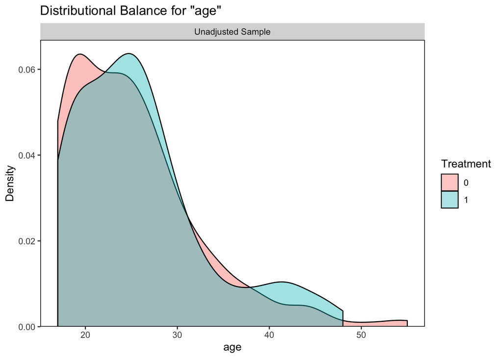

```r
# cobalt package has the most intuitive visualization functions
cobalt::bal.plot(nsw_dw %>% select(-data_id),
                treat = nsw_dw$treat,
                var.name = "age")
```

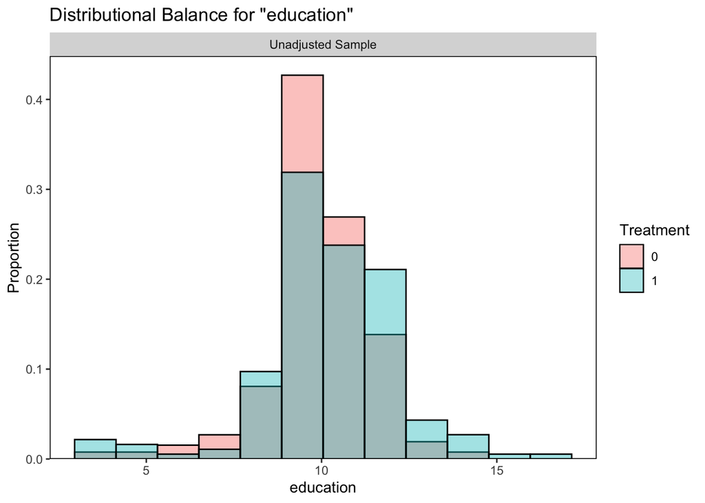

```r
cobalt::bal.plot(nsw_dw %>% select(-data_id),
                treat = nsw_dw$treat,
                var.name = "education",
                type = "histogram")
```

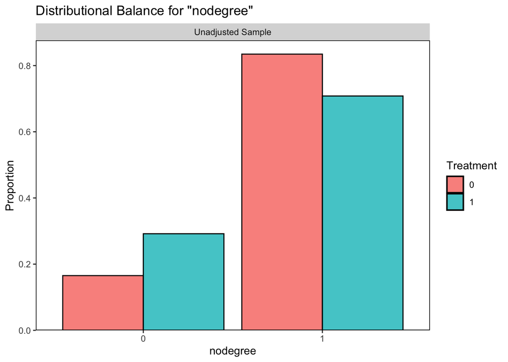

```r
cobalt::bal.plot(nsw_dw %>% select(-data_id),
                treat = nsw_dw$treat,
                var.name = "nodegree")
```

Once again, it is fairy evident that the experiment achieved good balance between the two groups.You can read about other functionalities available in `cobalt` in the following tutorial: [Guide to the `cobalt` Package](https://cran.r-project.org/web/packages/cobalt/vignettes/cobalt.html).

## 4.3 Merging PSID controls

Next, we remove experimental controls and combine treated subjects from `nsw_dw` with the PSID sample. This follows the steps taken in Lalonde (1986) to emulate a typical data collection process in an observational study.

```r
nsw_PSID <- nsw_dw %>%
  filter(treat==1) %>%
  bind_rows(PSID)

summary(nsw_PSID)
```

```
##    data_id              treat              age          education
##  Length:2675        Min.   :0.00000   Min.   :17.00   Min.   : 0.00
##  Class :character   1st Qu.:0.00000   1st Qu.:25.00   1st Qu.:10.00
##  Mode  :character   Median :0.00000   Median :32.00   Median :12.00
##                     Mean   :0.06916   Mean   :34.23   Mean   :11.99
##                     3rd Qu.:0.00000   3rd Qu.:43.50   3rd Qu.:14.00
##                     Max.   :1.00000   Max.   :55.00   Max.   :17.00
##      black           hispanic          married          nodegree
##  Min.   :0.0000   Min.   :0.00000   Min.   :0.0000   Min.   :0.0000
##  1st Qu.:0.0000   1st Qu.:0.00000   1st Qu.:1.0000   1st Qu.:0.0000
##  Median :0.0000   Median :0.00000   Median :1.0000   Median :0.0000
##  Mean   :0.2916   Mean   :0.03439   Mean   :0.8194   Mean   :0.3331
##  3rd Qu.:1.0000   3rd Qu.:0.00000   3rd Qu.:1.0000   3rd Qu.:1.0000
##  Max.   :1.0000   Max.   :1.00000   Max.   :1.0000   Max.   :1.0000
##       re74             re75             re78
##  Min.   :     0   Min.   :     0   Min.   :     0
##  1st Qu.:  8817   1st Qu.:  7605   1st Qu.:  9243
##  Median : 17437   Median : 17008   Median : 19432
##  Mean   : 18230   Mean   : 17851   Mean   : 20502
##  3rd Qu.: 25470   3rd Qu.: 25584   3rd Qu.: 28816
##  Max.   :137149   Max.   :156653   Max.   :121174
```

```r
sum(nsw_PSID$treat)
```

```
## [1] 185
```

The new combined data set contains 2,675 subjects, including 185 treated from the NSW data.

## 4.4 Exercise 1

**Balance in the combined data set**

1. Assess the balance in the combined data set using any routines outlined above, both analytic and graphical. Discuss your observations.

```r
##
```

2. Estimate the treatment effect using OLS, controlling for available background covariates.

```r
##
```

3. Discuss the following questions:
1. How does the estimated effect compare to the one from the randomized experiment?
2. Why do you think there is such discrepancy, even though we “controlled” for all pre-treatment variables?

**Click for Exercise 1 Solution**

1. Assess the balance in the combined data set using any routines outlined above, both analytic and graphical. Discuss your observations.

```r
## Let's use bal.tab
bal.tab(nsw_PSID %>% select(-data_id, -re78),
        treat = nsw_PSID$treat,
        disp.means = T,
        disp.sds = T,
        stats = c("mean.diffs", "variance.ratios", "ks.statistics"))
```

```
## Note: 's.d.denom' not specified; assuming pooled.
```

```
## Balance Measures
##              Type     M.0.Un    SD.0.Un    M.1.Un   SD.1.Un Diff.Un V.Ratio.Un
## age       Contin.    34.8506    10.4408   25.8162    7.1550 -1.0094     0.4696
## education Contin.    12.1169     3.0824   10.3459    2.0107 -0.6805     0.4255
## black      Binary     0.2506               0.8432            0.5926
## hispanic   Binary     0.0325               0.0595            0.0269
## married    Binary     0.8663               0.1892           -0.6771
## nodegree   Binary     0.3052               0.7081            0.4029
## re74      Contin. 19428.7458 13406.8772 2095.5737 4886.6204 -1.7178     0.1329
## re75      Contin. 19063.3377 13596.9549 1532.0553 3219.2509 -1.7744     0.0561
##            KS.Un
## age       0.3771
## education 0.4029
## black     0.5926
## hispanic  0.0269
## married   0.6771
## nodegree  0.4029
## re74      0.7292
## re75      0.7736
##
## Sample sizes
##     Control Treated
## All    2490     185
```

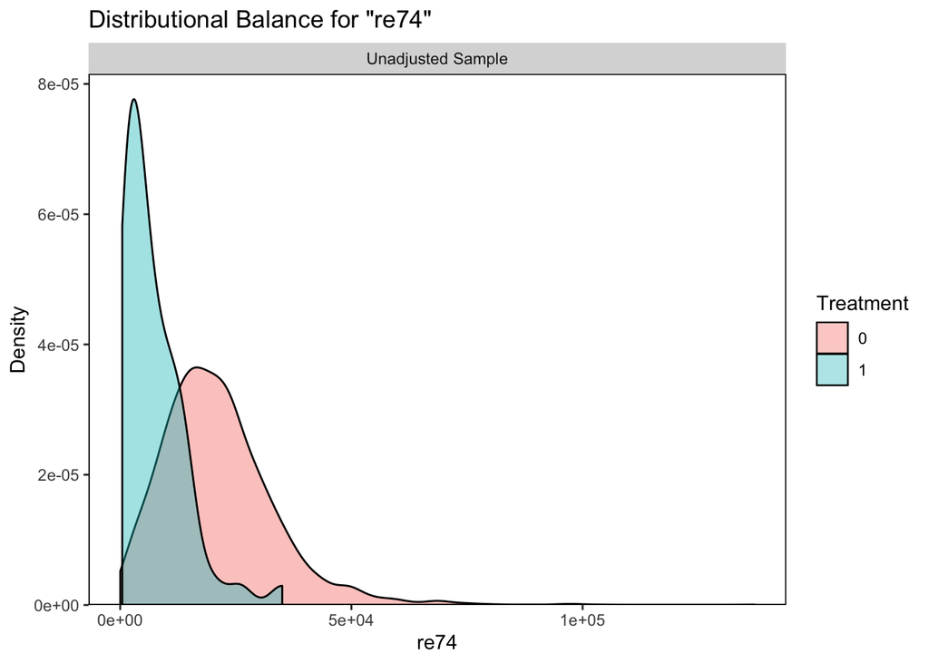

```r
nsw_PSID_posRE74 <- nsw_PSID %>% filter(re74>0)
bal.plot(nsw_PSID_posRE74,
         treat = nsw_PSID_posRE74$treat,
         var.name = "re74")
```

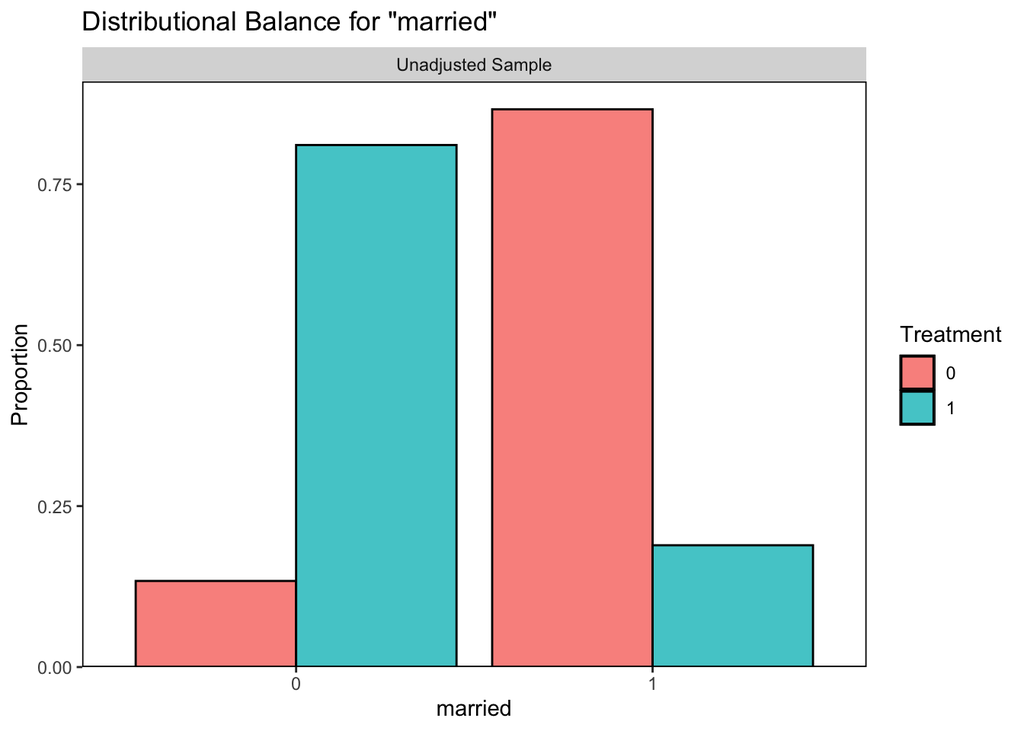

```r
bal.plot(nsw_PSID,
         treat = nsw_PSID$treat,
         var.name = "married")
```

The treated subjects tend to be younger, have fewer years of education, are less likely to be married, and earn a lot less in 1974 and 1975.

2. Estimate the treatment effect using OLS, controlling for available background covariates.

```r
# Treatment effect using regression adjustment
raw_mod <- lm(re78 ~ treat + age + education + black +
                hispanic + nodegree + married + re74 + re75,
                data = nsw_PSID)
summary(raw_mod)
```

```
##
## Call:
## lm(formula = re78 ~ treat + age + education + black + hispanic +
##     nodegree + married + re74 + re75, data = nsw_PSID)
##
## Residuals:
##    Min     1Q Median     3Q    Max
## -64870  -4302   -435   3786 110412
##
## Coefficients:
##               Estimate Std. Error t value Pr(>|t|)
## (Intercept) -129.74267 1688.51705  -0.077   0.9388
## treat        751.94636  915.25722   0.822   0.4114
## age          -83.56559   20.81380  -4.015 6.11e-05 ***
## education    592.61019  103.30278   5.737 1.07e-08 ***
## black       -570.92798  495.17772  -1.153   0.2490
## hispanic    2163.28116 1092.29036   1.981   0.0478 *
## nodegree     590.46694  646.78416   0.913   0.3614
## married     1240.51951  586.25390   2.116   0.0344 *
## re74           0.27812    0.02792   9.960  < 2e-16 ***
## re75           0.56809    0.02756  20.613  < 2e-16 ***
## ---
## Signif. codes:  0 '***' 0.001 '**' 0.01 '*' 0.05 '.' 0.1 ' ' 1
##
## Residual standard error: 10070 on 2665 degrees of freedom
## Multiple R-squared:  0.5864, Adjusted R-squared:  0.585
## F-statistic: 419.8 on 9 and 2665 DF,  p-value: < 2.2e-16
```

```r
confint(raw_mod)
```

```
##                     2.5 %       97.5 %
## (Intercept) -3440.6789935 3181.1936528
## treat       -1042.7399231 2546.6326360
## age          -124.3784144  -42.7527564
## education     390.0484754  795.1719123
## black       -1541.8994550  400.0434933
## hispanic       21.4586495 4305.1036682
## nodegree     -677.7827254 1858.7166030
## married        90.9608842 2390.0781379
## re74            0.2233653    0.3328768
## re75            0.5140503    0.6221322
```

3. Discuss the following questions:
1. How does the estimated effect compare to the one from the randomized experiment?
2. Why do you think there is such discrepancy, even though we “controlled” for all pre-treatment variables?

Answer:

1. The estimated effect ($752) is about half of the effect obtained from the experiment ($1,676). It is also not significant.
2. Drawing causal inference from OLS estimates is only appropriate when we can assume ignorability (i.e., we believe that treatment assignments only depend on information included in the model), and when the chosen outcome model is correct. Lack of overlap and balance forces stronger reliance on our modeling than if covariate distributions were the same across treatment groups. Considerable nonoverlap also makes the assumption about a constant treatment effect less plausible as well as results in heavy extrapolations.

# 5 Tools for Matching in R

There are a few R packages that perform data preprocessing and causal effect estimation:

- `MatchIt` Nonparametric Preprocessing for Parametric Causal Inference (Ho, Imai, King, & Stuart, 2011)
- `twang` Toolkit for Weighting and Analysis of Nonequivalent Groups (Ridgeway, McCaffrey, Morral, Burgette, & Griffin, 2020)
- `Matching` Multivariate and Propensity Score Matching with Balance Optimization (Sekhon, 2011)
- `cem` Coarsened Exact Matching (Iacus, King, & Porro, 2018)
- `optmatch` Functions for Optimal Matching (Hansen & Klopfer, 2006)
- `CBPS` Covariate Balancing Propensity Score (Fong, Ratkovic, Hazlett, Yang, & Imai, 2019),
- `ebal` Entropy reweighting to create balanced samples (Hainmueller, 2014)
- `sbw` Stable Balancing Weights for Causal Inference and Estimation with Incomplete Outcome Data (Zubizarreta & Li, 2019)
- `designmatch` Matched Samples that are Balanced and Representative by Design (Zubizarreta, Kilcioglu, & Vielma, 2018)
- `WeightIt` Weighting for Covariate Balance in Observational Studies (Greifer, 2020)
- `MatchThem` Matching and Weighting Multiply Imputed Datasets (Pishgar & Greifer, 2020)
- `PanelMatch` Matching Methods for Causal Inference with Time-Series Cross-Sectional Data (Imai, Kim, and Wang, 2018)
- `multilevelPSA` Multilevel Propensity Score Analysis (Bryer & Pruzek, 2011)
- `party` A Laboratory for Recursive Partytioning (Hothorn, Hornik, & Zeileis, 2006)
- `rpart` Recursive Partitioning (Therneau, Atkinson, & Ripley, 2012)
- `rbounds` An Overview of rebounds: An R Package for Rosenbaum bounds sensitivity analysis with matched data (Keele, 2010)
- `TriMatch`Propensity Score Matching for Non-Binary Treatments (Bryer, 2013)

The packages vary in ranges of available methods and functionalities but, together, provide a rich set of preprocessing tools. For a thorough review of some of them see Keller & Tipton (2016). Next we will explore functions from packages `MatchIt` and `cem`.

## 5.1 PS Matching with `MatchIt`

The default method in the `MatchIt` package is the Nearest Neighbor Matching, which (sequentially) selects the best control for each treated subject using distance between their estimated *propensity scores*. The end result is two groups with (hopefully) similar distributions of covariates.

```r
m_NNM_out <- MatchIt::matchit(treat ~ age + education + black + hispanic +
                                married + nodegree + re74 + re75,
                              data = nsw_PSID) # Try discard = "both"
summary(m_NNM_out) # Can add standardize = TRUE
```

```
##
## Call:
## MatchIt::matchit(formula = treat ~ age + education + black +
##     hispanic + married + nodegree + re74 + re75, data = nsw_PSID)
##
## Summary of balance for all data:
##           Means Treated Means Control SD Control   Mean Diff    eQQ Med
## distance         0.6364        0.0270     0.0992      0.6094     0.7267
## age             25.8162       34.8506    10.4408     -9.0344     8.0000
## education       10.3459       12.1169     3.0824     -1.7709     2.0000
## black            0.8432        0.2506     0.4334      0.5926     1.0000
## hispanic         0.0595        0.0325     0.1774      0.0269     0.0000
## married          0.1892        0.8663     0.3404     -0.6771     1.0000
## nodegree         0.7081        0.3052     0.4606      0.4029     0.0000
## re74          2095.5737    19428.7458 13406.8772 -17333.1721 18417.1074
## re75          1532.0553    19063.3377 13596.9549 -17531.2824 17903.2266
##             eQQ Mean     eQQ Max
## distance      0.6075      0.8817
## age           9.0432     17.0000
## education     1.8595      5.0000
## black         0.5892      1.0000
## hispanic      0.0270      1.0000
## married       0.6757      1.0000
## nodegree      0.4000      1.0000
## re74      17662.9118 102108.6172
## re75      17977.5835 131510.9941
##
##
## Summary of balance for matched data:
##           Means Treated Means Control SD Control  Mean Diff  eQQ Med  eQQ Mean
## distance         0.6364        0.2934     0.2319     0.3430    0.377    0.3430
## age             25.8162       30.4811    11.1077    -4.6649    2.000    4.6649
## education       10.3459       10.3784     2.9187    -0.0324    0.000    0.6919
## black            0.8432        0.7568     0.4302     0.0865    0.000    0.0865
## hispanic         0.0595        0.0649     0.2470    -0.0054    0.000    0.0054
## married          0.1892        0.4595     0.4997    -0.2703    0.000    0.2703
## nodegree         0.7081        0.6216     0.4863     0.0865    0.000    0.0865
## re74          2095.5737     4499.8428  4654.9584 -2404.2691 2006.289 2645.6165
## re75          1532.0553     3204.3968  3745.1931 -1672.3415 1994.419 1737.5551
##              eQQ Max
```

[output cut: 13 more lines]

```
## age          48.3654  75.0000  48.4160  5.8824
## education    98.1686 100.0000  62.7907 20.0000
## black        85.4066 100.0000  85.3211  0.0000
## hispanic     79.9274   0.0000  80.0000  0.0000
## married      60.0827 100.0000  60.0000  0.0000
## nodegree     78.5333   0.0000  78.3784  0.0000
## re74         86.1291  89.1064  85.0216 85.6468
## re75         90.4608  88.8600  90.3349 96.4558
##
## Sample sizes:
##           Control Treated
## All          2490     185
## Matched       185     185
## Unmatched    2305       0
## Discarded       0       0
```

```r
## `cobalt` package offers additional summaries of distributional differences
## Note that it can process objects returned by matchit()!
cobalt::bal.tab(m_NNM_out,
                disp.means = T,
                disp.sds = T,
                stats = c("mean.diffs", "variance.ratios", "ks.statistics"))
```

```
## Call
##  MatchIt::matchit(formula = treat ~ age + education + black +
##     hispanic + married + nodegree + re74 + re75, data = nsw_PSID)
##
## Balance Measures
##               Type   M.0.Adj  SD.0.Adj   M.1.Adj  SD.1.Adj Diff.Adj V.Ratio.Adj
## distance  Distance    0.2934    0.2319    0.6364    0.2812   1.2200      1.4702
## age        Contin.   30.4811   11.1077   25.8162    7.1550  -0.6520      0.4149
## education  Contin.   10.3784    2.9187   10.3459    2.0107  -0.0161      0.4745
## black       Binary    0.7568              0.8432             0.0865
## hispanic    Binary    0.0649              0.0595            -0.0054
## married     Binary    0.4595              0.1892            -0.2703
## nodegree    Binary    0.6216              0.7081             0.0865
## re74       Contin. 4499.8428 4654.9584 2095.5737 4886.6204  -0.4920      1.1020
## re75       Contin. 3204.3968 3745.1931 1532.0553 3219.2509  -0.5195      0.7389
##           KS.Adj
## distance  0.5568
## age       0.1784
## education 0.0919
## black     0.0865
## hispanic  0.0054
## married   0.2703
## nodegree  0.0865
## re74      0.4162
## re75      0.2973
##
## Sample sizes
##           Control Treated
## All          2490     185
## Matched       185     185
## Unmatched    2305       0
```

This should run fairly quickly! The next step is to investigate the results of the matching procedure. Did we improve balance? Are the selected comparison units similar to treated units across age, race, education, marital status, and prior earnings? The quickest way to check this is to plot a summary of the results, like so:

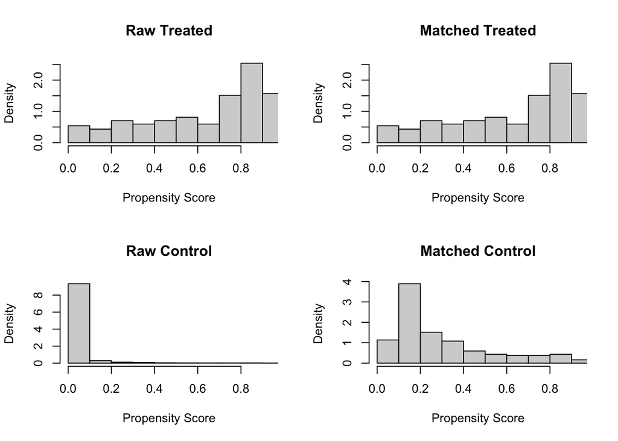

```r
# The default plotting function in `MatchIt`
# Compare the distribution of propensity scores before and after matching
plot(m_NNM_out, type = "hist")
```

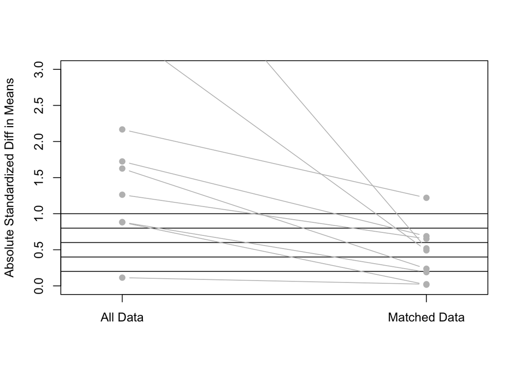

```r
# Compare standardized mean differences before/after
s.out <- summary(m_NNM_out, standardize = TRUE)
plot(s.out, interactive = F)
```

The default plotting function in `MatchIt` is somewhat clunky. Again, we can use functions from `cobalt` to make pretty plots using objects generated by `matchit()`.

The *Love plot* is a summary plot of covariate balance before and after conditioning popularized by Dr. Thomas Love. In a visually appealing and clear way, it can help demonstrate that balance has been met within a threshold, and that balance has improved after conditioning.

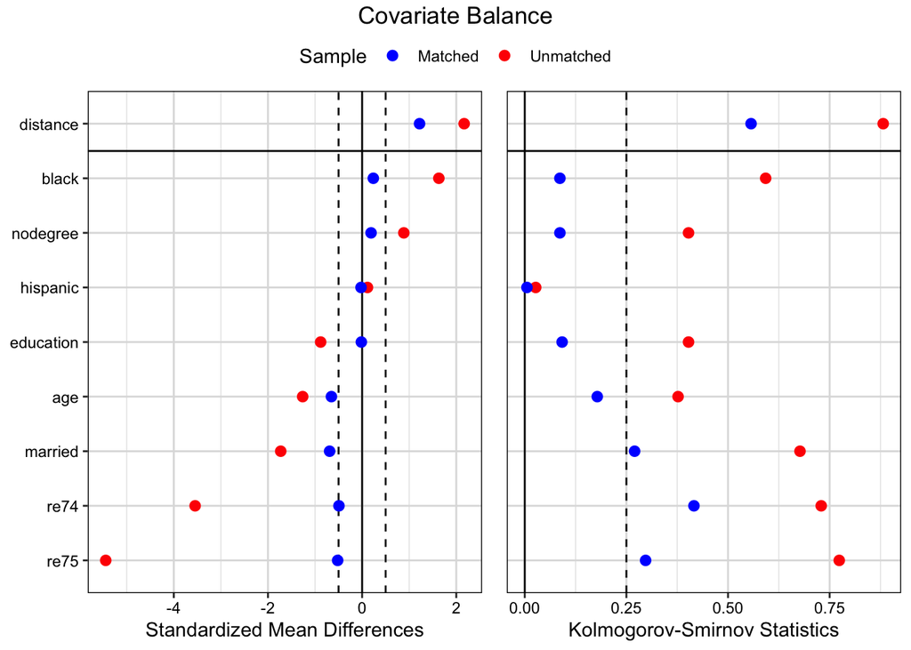

```r
cobalt::love.plot(m_NNM_out,
                  stats = c("mean.diffs", "ks.statistics"),
                  threshold = c(m = .5, ks = .25),
                  binary = "std", #display standardized mean difference for all of the covariates
                  #abs = TRUE,
                  var.order = "unadjusted", #how to order the variables in the plot
                  grid = T,
                  sample.names = c("Matched", "Unmatched"), #new names to be given to the samples
                  position = "top",
                  colors = c("blue", "red"))
```

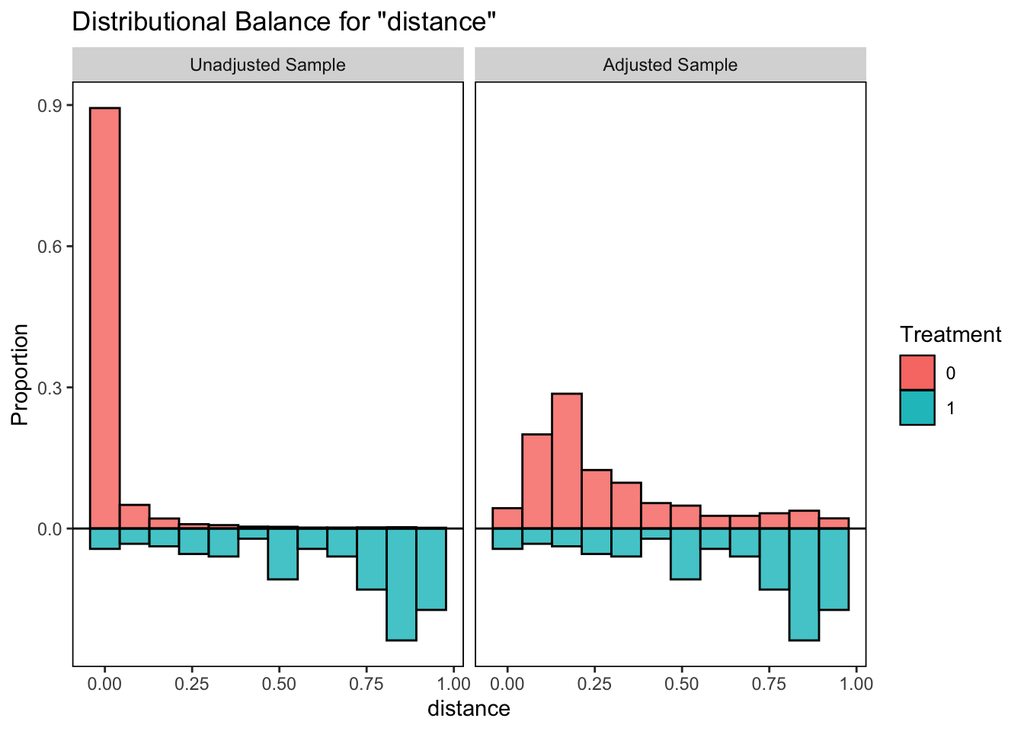

```r
# Propensity Scores before and after weighting (which = "both")
cobalt::bal.plot(m_NNM_out,
                 var.name = "distance",
                 which = "both", #what distributional balance to display
                 type = "histogram",
                 mirror = TRUE)
```

Even though we haven’t achieved a perfect balance, we will hope that the remaining discrepancy is adequately controlled by an OLS regression. For that, we first extract the matched data set using `MatchIt::match.data`.

```r
# Extracting the matched data set
m.data.NNM <- MatchIt::match.data(m_NNM_out)
summary(m.data.NNM)
```

```
##    data_id              treat          age          education         black
##  Length:370         Min.   :0.0   Min.   :17.00   Min.   : 3.00   Min.   :0.0
##  Class :character   1st Qu.:0.0   1st Qu.:21.00   1st Qu.: 9.00   1st Qu.:1.0
##  Mode  :character   Median :0.5   Median :25.00   Median :11.00   Median :1.0
##                     Mean   :0.5   Mean   :28.15   Mean   :10.36   Mean   :0.8
##                     3rd Qu.:1.0   3rd Qu.:31.00   3rd Qu.:12.00   3rd Qu.:1.0
##                     Max.   :1.0   Max.   :55.00   Max.   :17.00   Max.   :1.0
##     hispanic          married          nodegree           re74
##  Min.   :0.00000   Min.   :0.0000   Min.   :0.0000   Min.   :    0.00
##  1st Qu.:0.00000   1st Qu.:0.0000   1st Qu.:0.0000   1st Qu.:    0.00
##  Median :0.00000   Median :0.0000   Median :1.0000   Median :    8.82
##  Mean   :0.06216   Mean   :0.3243   Mean   :0.6649   Mean   : 3297.71
##  3rd Qu.:0.00000   3rd Qu.:1.0000   3rd Qu.:1.0000   3rd Qu.: 5681.87
##  Max.   :1.00000   Max.   :1.0000   Max.   :1.0000   Max.   :35040.07
##       re75              re78          distance            weights
##  Min.   :    0.0   Min.   :    0   Min.   :0.0002345   Min.   :1
##  1st Qu.:    0.0   1st Qu.:    0   1st Qu.:0.1783501   1st Qu.:1
##  Median :  164.1   Median : 4697   Median :0.4178355   Median :1
##  Mean   : 2368.2   Mean   : 6406   Mean   :0.4648903   Mean   :1
##  3rd Qu.: 3795.5   3rd Qu.: 9961   3rd Qu.:0.7924988   3rd Qu.:1
##  Max.   :25142.2   Max.   :60308   Max.   :0.9350264   Max.   :1
```

```r
m.data.NNM$treat %>% table
```

```
## .
##   0   1
## 185 185
```

```r
# Re-estimating the treatment effect using regression adjustment
NNM_mod <- lm(re78 ~ treat + age + education + black + hispanic +
                nodegree + married + re74 + re75,
              data = m.data.NNM)
summary(NNM_mod)
```

```
##
## Call:
## lm(formula = re78 ~ treat + age + education + black + hispanic +
##     nodegree + married + re74 + re75, data = m.data.NNM)
##
## Residuals:
##    Min     1Q Median     3Q    Max
## -12395  -4563  -1013   2915  54877
##
## Coefficients:
##               Estimate Std. Error t value Pr(>|t|)
## (Intercept)  2.058e+03  3.698e+03   0.556   0.5782
## treat        1.084e+03  8.235e+02   1.316   0.1890
## age         -6.179e+01  4.605e+01  -1.342   0.1805
## education    4.528e+02  2.197e+02   2.061   0.0401 *
## black       -2.726e+02  1.141e+03  -0.239   0.8113
## hispanic    -3.588e+02  1.811e+03  -0.198   0.8431
## nodegree    -1.080e+03  1.091e+03  -0.990   0.3228
## married      1.497e+03  8.741e+02   1.712   0.0877 .
## re74         1.835e-01  9.599e-02   1.911   0.0567 .
## re75         3.047e-01  1.299e-01   2.346   0.0195 *
## ---
## Signif. codes:  0 '***' 0.001 '**' 0.01 '*' 0.05 '.' 0.1 ' ' 1
##
## Residual standard error: 7020 on 360 degrees of freedom
## Multiple R-squared:  0.1322, Adjusted R-squared:  0.1105
## F-statistic: 6.093 on 9 and 360 DF,  p-value: 5.55e-08
```

```r
confint(NNM_mod)
```

```
##                     2.5 %       97.5 %
## (Intercept) -5.214064e+03 9329.3285743
## treat       -5.356871e+02 2703.3411299
## age         -1.523510e+02   28.7726453
## education    2.065763e+01  884.8567013
## black       -2.517094e+03 1971.8477442
## hispanic    -3.920666e+03 3203.0848552
## nodegree    -3.224450e+03 1064.9646654
## married     -2.221203e+02 3215.7927406
## re74        -5.289760e-03    0.3722581
## re75         4.927121e-02    0.5600429
```

Note that the estimated treatment effect ($1,084) is closer to the one obtained from the experiment ($1,676) and its 95% CI contains this value.

`MatchIt` offers other matching techniques, including exact matching, full matching, and k:1 matching with replacement, some of which are enabled by loading other add-on packages in the background. Read more about all the available options here: [Ho, Imai, King, Stuart 2011, “MatchIt: Nonparametric Preprocessing for Parametric Causal Inference.” Journal of Statistical Software](https://gking.harvard.edu/files/gking/files/v42i08.pdf).

Next, we will practice matching using another package called `cem`.

## 5.2 Matching with `cem`

Package `cem` performs an automatic Coarsened Exact Matching (CEM) using the following steps:

1. *Temporarily* coarsen each covariate in a user-defined (or automated) way.
2. Sort all units into strata, each of which has the same values of the coarsened X.
3. Discard all units in those strata that do not include at least one treated and one control unit.

`cem` also offers its own functions for checking balance between groups:

```r
## While not as consequential for propensity-score matching, it is important
## to preprocess the data set before running CEM and convert to factors all
## non-numeric covariates to ensure that "binning" is performed correctly:

nsw_PSID_cem <-
  nsw_PSID %>%
    mutate_at(vars(black, hispanic, married, nodegree), ~as.factor(.)) %>%
    as.data.frame

# Balance checking via cem package
cem::imbalance(group = nsw_PSID_cem$treat,
               data  = nsw_PSID_cem,
               drop  = c("treat", "re78", "data_id"))
```

```
##
## Multivariate Imbalance Measure: L1=0.986
## Percentage of local common support: LCS=1.4%
##
## Univariate Imbalance Measures:
##
##               statistic   type         L1 min        25%       50%       75%
## age           -9.034386 (diff) 0.18616086  -1     -6.000     -8.00    -15.00
## education     -1.770922 (diff) 0.44048627   4     -2.000     -1.00     -2.00
## black        289.940097 (Chi2) 0.59264083  NA         NA        NA        NA
## hispanic       2.993226 (Chi2) 0.02692934  NA         NA        NA        NA
## married      528.991963 (Chi2) 0.67707587  NA         NA        NA        NA
## nodegree     124.024343 (Chi2) 0.40288722  NA         NA        NA        NA
## re74      -17333.172112 (diff) 0.00000000   0 -10775.967 -18417.11 -25158.63
## re75      -17531.282355 (diff) 0.00000000   0  -9846.774 -17903.23 -24679.49
##                 max
## age            -7.0
## education      -1.0
## black            NA
## hispanic         NA
## married          NA
## nodegree         NA
## re74      -102108.6
## re75      -131511.0
```

L1 statistic from the output above measures differences between the uni- (and multi-) dimensional histograms of all covariates in the two groups. Perfect (up to discretization) global balance result in L1 = 0. Whereas, L1 = 1 indicates complete separation of the multidimensional histograms. Any value in the interval (0, 1) indicates the amount of difference between frequencies of units in strata for each coarsened covariate of the two groups.

In our case, the multivariate imbalanced measure (L1) is close to 1, suggesting an almost complete separation. The differences in the empirical quantiles of the two distributions (same as eQQ statistics reported by `MatchIt`) also indicate a large amount of imbalance for many covariates.

Let’s now perform CEM on our observational data:

```r
## It is advised to prespecify relevant cutpoints for continuous covariates
edu_cut <- c(0, 8.5, 12.5, 17)
re_cut <- c(0, 2500, 5000, 7500, 10000, 15000, 20000, 50000, 100000, 200000)

m_cem_out <-
  cem::cem(treatment = "treat",
           data = nsw_PSID_cem,
           verbose = TRUE,
           keep.all = TRUE, # coarsened dataset is returned
           drop = c("re78", "data_id"),
           cutpoints = list(education = edu_cut,
                            re75 = re_cut))
```

```
##
## Using 'treat'='1' as baseline group
```

```r
m_cem_out
```

```
##             G0  G1
## All       2490 185
## Matched     71 111
## Unmatched 2419  74
```

Note that, unlike NNM example in `MatchIt`, CEM method dropped a few (74) treated units and a vast majority of control units in strata that did not have any comparables from the other groups. (Note that we could’ve specified `discard = "both"` in `matchit()` to remove units that fall outside of some measure of support before matching).

`cem()` used prespecified breaks for the corresponding variables and calculated the breaks automatically for the rest:

```r
m_cem_out$breaks
```

```
## $age
##  [1] 17.00000 20.16667 23.33333 26.50000 29.66667 32.83333 36.00000 39.16667
##  [9] 42.33333 45.50000 48.66667 51.83333 55.00000
##
## $education
## [1]  0.0  8.5 12.5 17.0
##
## $re74
##  [1]      0.00  11429.06  22858.11  34287.17  45716.23  57145.29  68574.34
##  [8]  80003.40  91432.46 102861.52 114290.57 125719.63 137148.69
##
## $re75
##  [1]      0   2500   5000   7500  10000  15000  20000  50000 100000 200000
```

We can also explore how the subjects were matched:

```r
# Strata that had at least one treatment and one control subject
m_cem_out$mstrataID
```

```
##  [1]  1  6  7  8 10 11 12 13 14 16 19 22 26 27 31 33 38 41 44 49 51 59 60 61 62
## [26] 64 68 71 75 76 77 84 86 88 89 90
```

```r
nsw_PSID_cem %>%
  mutate(strata_num = m_cem_out$mstrata) %>%
  arrange(strata_num) %>%
  select(-data_id) %>%
  kable %>%
  kable_styling() %>%
  scroll_box(width = "800", height = "400px")
```

| treat | age | education | black | hispanic | married | nodegree | re74 | re75 | re78 | strata_num |
| --- | --- | --- | --- | --- | --- | --- | --- | --- | --- | --- |
| 1 | 37 | 11 | 1 | 0 | 1 | 1 | 0.0000 | 0.00000 | 9930.04590 | 1 |
| 0 | 38 | 10 | 1 | 0 | 1 | 1 | 5877.8003 | 0.00000 | 0.00000 | 1 |
| 1 | 22 | 9 | 1 | 0 | 0 | 1 | 0.0000 | 0.00000 | 4056.49390 | 6 |
| 1 | 23 | 10 | 1 | 0 | 0 | 1 | 0.0000 | 0.00000 | 7693.39990 | 6 |
| 1 | 23 | 11 | 1 | 0 | 0 | 1 | 0.0000 | 0.00000 | 0.00000 | 6 |
| 1 | 21 | 9 | 1 | 0 | 0 | 1 | 0.0000 | 0.00000 | 0.00000 | 6 |
| 1 | 22 | 11 | 1 | 0 | 0 | 1 | 0.0000 | 0.00000 | 6456.69678 | 6 |
| 0 | 23 | 9 | 1 | 0 | 0 | 1 | 0.0000 | 0.00000 | 218.70354 | 6 |
| 0 | 23 | 11 | 1 | 0 | 0 | 1 | 0.0000 | 0.00000 | 0.00000 | 6 |
| 0 | 23 | 11 | 1 | 0 | 0 | 1 | 0.0000 | 0.00000 | 0.00000 | 6 |
| 0 | 22 | 11 | 1 | 0 | 0 | 1 | 2351.1201 | 0.00000 | 879.24731 | 6 |
| 1 | 23 | 12 | 1 | 0 | 0 | 0 | 0.0000 | 0.00000 | 0.00000 | 7 |
| 1 | 21 | 12 | 1 | 0 | 0 | 0 | 0.0000 | 0.00000 | 1254.58203 | 7 |
| 1 | 23 | 12 | 1 | 0 | 0 | 0 | 0.0000 | 0.00000 | 4843.17578 | 7 |
| 1 | 22 | 12 | 1 | 0 | 0 | 0 | 0.0000 | 0.00000 | 18678.08008 | 7 |
| 1 | 21 | 12 | 1 | 0 | 0 | 0 | 0.0000 | 0.00000 | 9983.78418 | 7 |
| 1 | 23 | 12 | 1 | 0 | 0 | 0 | 5506.3081 | 501.07410 | 671.33179 | 7 |
| 1 | 22 | 12 | 1 | 0 | 0 | 0 | 5605.8521 | 936.17731 | 0.00000 | 7 |
| 0 | 23 | 12 | 1 | 0 | 0 | 0 | 0.0000 | 0.00000 | 4728.72510 | 7 |
| 1 | 32 | 11 | 1 | 0 | 0 | 1 | 0.0000 | 0.00000 | 8472.15820 | 8 |
| 1 | 30 | 11 | 1 | 0 | 0 | 1 | 0.0000 | 0.00000 | 0.00000 | 8 |
| 1 | 31 | 9 | 1 | 0 | 0 | 1 | 0.0000 | 1698.60706 | 10363.26953 | 8 |
| 0 | 30 | 9 | 1 | 0 | 0 | 1 | 1959.2668 | 162.91936 | 16809.14062 | 8 |
| 1 | 33 | 12 | 0 | 0 | 1 | 0 | 0.0000 | 0.00000 | 12418.07031 | 10 |
| 0 | 34 | 12 | 0 | 0 | 1 | 0 | 0.0000 | 0.00000 | 0.00000 | 10 |
| 0 | 33 | 12 | 0 | 0 | 1 | 0 | 0.0000 | 0.00000 | 0.00000 | 10 |
| 0 | 34 | 12 | 0 | 0 | 1 | 0 | 0.0000 | 0.00000 | 0.00000 | 10 |
| 0 | 33 | 12 | 0 | 0 | 1 | 0 | 2351.1201 | 0.00000 | 2770.73730 | 10 |
| 1 | 19 | 9 | 1 | 0 | 0 | 1 | 0.0000 | 0.00000 | 8173.90820 | 11 |
| 1 | 19 | 10 | 1 | 0 | 0 | 1 | 0.0000 | 0.00000 | 3228.50293 | 11 |

[output cut: 2645 more lines]

Let’s examine the resulting balance:

```r
cobalt::bal.tab(m_cem_out,
                data =  nsw_PSID_cem, # Data must be specified for `cem` objects
                disp.means = T,
                disp.sds = T,
                stats = c("mean.diffs", "variance.ratios", "ks.statistics"))
```

```
## Balance Measures
##              Type   M.0.Adj SD.0.Adj   M.1.Adj  SD.1.Adj Diff.Adj V.Ratio.Adj
## age       Contin.   24.6697    6.065   24.1261    6.0394  -0.0760      0.9916
## education Contin.   10.7868    1.956   10.4324    1.6982  -0.1762      0.7538
## black      Binary    0.9550             0.9550             0.0000
## hispanic   Binary    0.0000             0.0000             0.0000
## married    Binary    0.2252             0.2252             0.0000
## nodegree   Binary    0.7387             0.7387             0.0000
## re74      Contin. 3172.9223 4193.724 1609.9595 3549.5576  -0.3198      0.7164
## re75      Contin. 1400.0887 3510.904 1491.9022 3579.8715   0.0285      1.0397
##           KS.Adj
## age       0.1802
## education 0.1899
## black     0.0000
## hispanic  0.0000
## married   0.0000
## nodegree  0.0000
## re74      0.4284
## re75      0.1275
##
## Sample sizes
##                      Control Treated
## All                  2490.       185
## Matched (ESS)          14.67     111
## Matched (Unweighted)   71.       111
## Unmatched            2419.        74
```

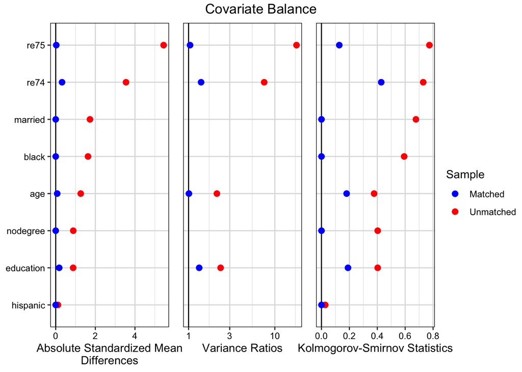

```r
cobalt::love.plot(m_cem_out,
                  stats = c("mean.diffs", "variance.ratios", "ks.statistics"),
                  data = nsw_PSID_cem,
                 # threshold = c(m = .5, ks = .25),
                  binary = "std",
                  abs = TRUE,
                  var.order = "unadjusted",
                  grid = T,
                  sample.names = c("Matched", "Unmatched"),
                  colors = c("blue", "red"))
```

We’ve achieved a much better balance. However, lost many degrees of freedom by considerably pruning the treated group. Also, note that since we dropped quite a few units from the treatment group, our target population of treated units have changed and we need to acknowledge that and disclose when reporting the results of the analysis.

## 5.3 Estimating ATT with `cem`

Because `cem` results in a *stratified data set*, we have to use a special function `cem::att()` (which stands for “Average Treatment effect on the Treated”) to estimate the treatment effect. It takes CEM output and applies a `model` of user’s choice, using a specified `formula`:

```r
## Need to exclude hispanic from the model as none were matched
est <- att(m_cem_out,
           re78 ~ treat + age + education + black + #hispanic
             nodegree + married + re74 + re75,
           data = nsw_PSID_cem)
summary(est)
```

```
##
## Treatment effect estimation for data:
##
##             G0  G1
## All       2490 185
## Matched     71 111
## Unmatched 2419  74
##
## Linear regression model estimated on matched data only
##
## Coefficients:
##                Estimate  Std. Error t value p-value
## (Intercept) -7276.10189  5524.08616 -1.3172 0.18953
## treat        1767.34678  1000.09179  1.7672 0.07896 .
## age           222.38810    97.22261  2.2874 0.02338 *
## education     547.90582   343.28229  1.5961 0.11230
## black1       1153.87426  2409.26565  0.4789 0.63259
## nodegree1   -1614.53273  1491.54480 -1.0825 0.28056
## married1      596.96804  1425.24741  0.4189 0.67584
## re74            0.11987     0.19858  0.6036 0.54688
## re75            0.21496     0.20719  1.0375 0.30096
## ---
## Signif. codes:  0 '***' 0.001 '**' 0.01 '*' 0.05 '.' 0.1 ' ' 1
```

The estimate of the treatment effect ($1767) is very close to the one obtained from the randomized experiment.

For more on `cem` package check out [Iacus, King, Porro, 2009, “CEM: Software for Coarsened Exact Matching.” Journal of Statistical Software](https://gking.harvard.edu/files/gking/files/jss-paper.pdf).

## 5.4 Exercise 2*

**Progressive coarsening with `cem`**

Although the maximum imbalance is fixed by the user’s coarsening choices, the number of observations matched is determined as a consequence of the matching procedure. If you are dissatisfied with the number of observations available after matching, and you feel that it is substantively appropriate to coarsen further, then just increase the coarsening (by using fewer cutpoints). The result will be additional matches, though the maximum possible imbalance between the treated and control groups would also go up.

This is easy with CEM because CEM is a monotonic imbalance bounding (MIB) method, which means that increasing the imbalance on one variable (by widening the coarsened bin sizes) will not change the maximum imbalance on any other variable. MIB thus enables you to tinker with the solution one variable at a time to quickly produce a satisfactory result, if one is feasible.

`cem` offers an automated way to relax the initial coarsening with a function `relax.cem()`. This function starts with the output of `cem()` and relaxes variables one (`depth = 1`), two (`depth = 2`), or three (`depth = 3`) at a time, while optionally keeping unchanged a chosen subset of the variables which we know well or have important effects on the outcome (`fixed`). The function also allows to specify the minimal number of breaks for each variable (`minimal`, set to 1 by default).

Review the documentation on `relax.cem()` and perform coarsened matching with `depth = 1`. Examine the resulting tables and a summary graph. Which variables are the hardest to match on?

```r
##
```

**Click for Exercise 2* Solution**

```r
## Let's use bal.tab
prog_cem  <- relax.cem(m_cem_out, nsw_PSID_cem, depth = 1)
```

```
## Executing 33 different relaxations
##
```

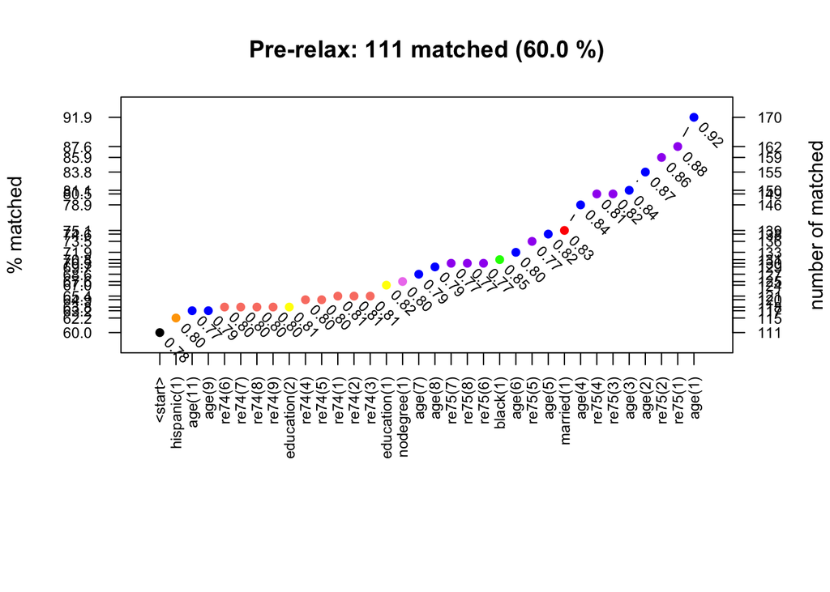

```r
prog_cem
```

```
## $G0
##    G0  G1   PercG0   PercG1      Relaxed        L1       var
## 1  71 111 2.851406 60.00000      <start> 0.7792158   <start>
## 2  78 117 3.132530 63.24324      age(11) 0.7735043       age
## 3  80 115 3.212851 62.16216  hispanic(1) 0.7967391  hispanic
## 4  83 129 3.333333 69.72973       age(8) 0.7907911       age
## 5  84 118 3.373494 63.78378      re74(6) 0.7962066      re74
## 6  84 118 3.373494 63.78378      re74(7) 0.7962066      re74
## 7  84 118 3.373494 63.78378      re74(8) 0.7962066      re74
## 8  84 118 3.373494 63.78378      re74(9) 0.7962066      re74
## 9  86 117 3.453815 63.24324       age(9) 0.7866229       age
## 10 89 125 3.574297 67.56757  nodegree(1) 0.8044045  nodegree
## 11 91 130 3.654618 70.27027      re75(7) 0.7681319      re75
## 12 91 130 3.654618 70.27027      re75(8) 0.7681319      re75
## 13 93 118 3.734940 63.78378 education(2) 0.8077274 education
## 14 93 120 3.734940 64.86486      re74(4) 0.8008065      re74
##  [ reached 'max' / getOption("max.print") -- omitted 20 rows ]
##
## $G1
##    G0  G1   PercG0   PercG1      Relaxed        L1       var
## 1  71 111 2.851406 60.00000      <start> 0.7792158   <start>
## 3  80 115 3.212851 62.16216  hispanic(1) 0.7967391  hispanic
## 2  78 117 3.132530 63.24324      age(11) 0.7735043       age
## 9  86 117 3.453815 63.24324       age(9) 0.7866229       age
## 5  84 118 3.373494 63.78378      re74(6) 0.7962066      re74
## 6  84 118 3.373494 63.78378      re74(7) 0.7962066      re74
## 7  84 118 3.373494 63.78378      re74(8) 0.7962066      re74
## 8  84 118 3.373494 63.78378      re74(9) 0.7962066      re74
## 13 93 118 3.734940 63.78378 education(2) 0.8077274 education
## 14 93 120 3.734940 64.86486      re74(4) 0.8008065      re74
## 15 93 120 3.734940 64.86486      re74(5) 0.8008065      re74
## 18 97 121 3.895582 65.40541      re74(1) 0.8059981      re74
## 19 97 121 3.895582 65.40541      re74(2) 0.8059981      re74
## 20 97 121 3.895582 65.40541      re74(3) 0.8059981      re74
##  [ reached 'max' / getOption("max.print") -- omitted 20 rows ]
##
## $L1breaks
## $L1breaks$data_id
## character(0)
##
```

[output cut: 26 more lines]

```
##
## $L1breaks$re75
##  [1]      0   5000  10000  15000  20000  25000  30000  35000  40000  45000
## [11]  50000  55000  60000  65000  70000  75000  80000  85000  90000  95000
## [21] 100000 105000 110000 115000 120000 125000 130000 135000 140000 145000
## [31] 150000 155000 160000
##
## $L1breaks$re78
##  [1]      0   5000  10000  15000  20000  25000  30000  35000  40000  45000
## [11]  50000  55000  60000  65000  70000  75000  80000  85000  90000  95000
## [21] 100000 105000 110000 115000 120000 125000
##
##
## attr(,"class")
## [1] "relax.cem"
```

## 5.5 Conclusion

We’ve only scratches the surface on available R packages, methods that they offer, and options available for these methods. We found that R documentation for many of them is sparse. However, it helps to review the accompanying publications as well as search around for examples developed by other users.

## 5.6 Wrap-up

### 5.6.1 Feedback

This workshop is a work in progress. Please provide any feedback to: research@hbs.edu.

### 5.6.2 Resources

- IQSS
  - Workshops: https://dss.iq.harvard.edu/workshop-materials
  - Data Science Services: https://dss.iq.harvard.edu/
  - Research Computing Environment: https://iqss.github.io/dss-rce/
- HBS
  - Research Computing Services workshops: https://training.rcs.hbs.org/workshops
  - Other HBS RCS resources: https://training.rcs.hbs.org/workshop-materials
  - RCS consulting email: mailto:research@hbs.edu